# Python tutorial

`subcortex_visualization` is an open-source Python package for programmatically visualizing region-level data across sixteen popular atlases for the subcortex (including thalamic nuclei and the brainstem) and cerebellum. Visualizations are rendered as resolution-independent two-dimensional vector graphics, inspired by the [`ggseg` R package](https://github.com/ggsegverse/ggseg) for cortical data, with standardized rendering conventions that make results directly comparable across atlases.

This tutorial covers the core functionality of the package:

1. **Exploring the built-in atlases** — viewing the sixteen included atlases with default and custom colormaps
2. **Choosing view angles** — displaying medial, lateral, superior, and inferior views
3. **Controlling transparency** — global alpha and significance-based transparency
4. **Working with your own data** — formatting and plotting empirical region-level data
5. **Extracting regional statistics from volumetric data** — using `parcel_segstats` to parcellate NIfTI images
6. **Combining cortical and subcortical visualizations** — integrating with `neuromaps` for whole-brain figures

An equivalent R package, `subcortexVisualizationR`, provides the same functionality and atlases with a nearly identical interface.

```python
import pandas as pd
import numpy as np
import matplotlib
import matplotlib.pyplot as plt
import matplotlib.colors as mcolors
import os

from subcortex_visualization.plotting import plot_subcortical_data
from subcortex_visualization.utils import get_atlas_regions
from subcortex_visualization import segmentation, plotting
```

## 1. Exploring the built-in atlases

The package includes sixteen pre-vectorized subcortical and cerebellar atlases that serve as scaffolds for visualizing region-level summary statistics:

[output not shown]

### `plot_subcortical_data`

The central function is `plot_subcortical_data`. With default parameters, it plots one color per region using the `viridis` colormap for the left hemisphere of the aseg subcortex atlas. More information about function arguments can be found in the API reference for [Python](https://anniegbryant.github.io/subcortex_visualization/python_api) and [R](https://anniegbryant.github.io/subcortex_visualization/R_api).

```python
from subcortex_visualization.plotting import plot_subcortical_data

plot_subcortical_data(fill_title="Demonstrating default parameters")
```

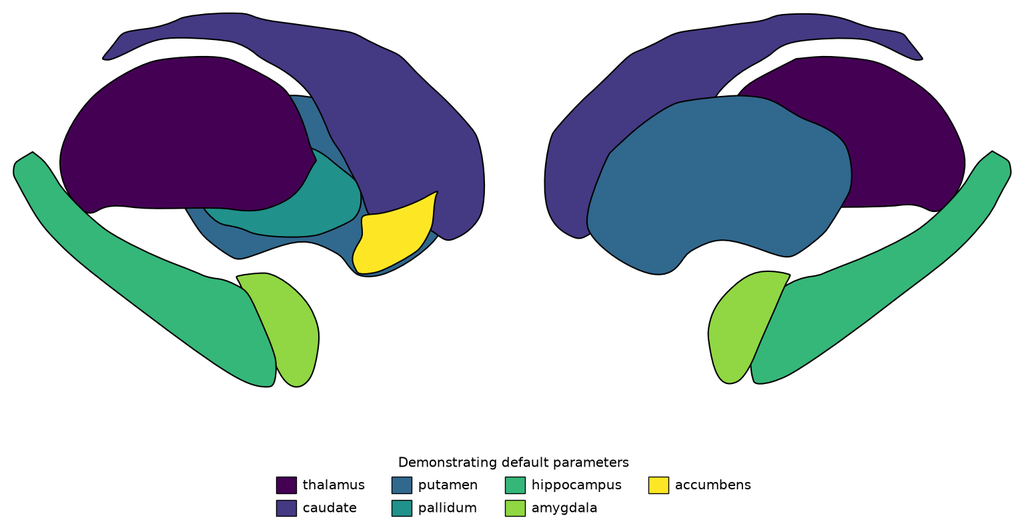

```python
from subcortex_visualization.plotting import plot_subcortical_data

# A. AICHA subcortex atlas, plasma colormap
plot_subcortical_data(atlas="AICHA_subcortex", cmap="plasma", hemisphere='both',
                      fill_title="AICHA with plasma colormap")

# B. Brainnetome subcortex atlas, rainbow colormap
plot_subcortical_data(atlas="Brainnetome_subcortex", cmap="hsv", hemisphere='both',
                      fill_title="Brainnetome subcortex with rainbow colormap")
```

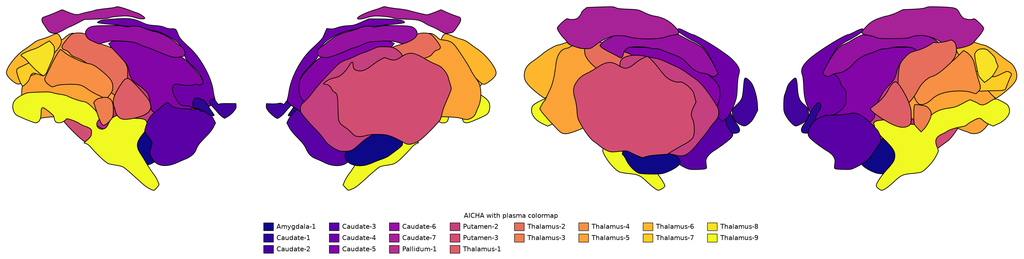

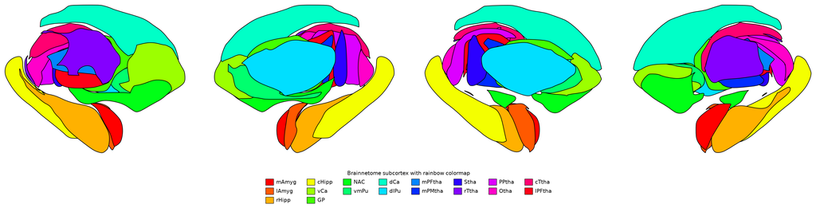

## 2. Choosing view angles

For each atlas, medial, lateral, superior, and inferior views are available for both hemispheres, either separately or combined. By default, `plot_subcortical_data` shows medial and lateral views. You can specify any combination with the `views` argument.

The one exception is the SUIT cerebellar lobule atlas, which is based on a two-dimensional flatmap representation of the cerebellum and is not designed to be shown in three-dimensional views.

Here we demonstrate all four views with the THOMAS thalamic nuclei atlas and the Brainstem Navigator atlas:

```python
from subcortex_visualization.plotting import plot_subcortical_data
from matplotlib import colors as mcolors

# A. THOMAS thalamic nuclei atlas
THOMAS_cmap = mcolors.LinearSegmentedColormap.from_list("", ["white", "#d14662"])
plot_subcortical_data(atlas="Thalamus_THOMAS", cmap=THOMAS_cmap, hemisphere='both',
                      views=['lateral', 'medial', 'superior', 'inferior'],
                      show_legend=False, fill_title="THOMAS thalamic nuclei")

# B. Brainstem Navigator atlas
Brainstem_cmap = mcolors.LinearSegmentedColormap.from_list("", ["white", "#c8499b"])
plot_subcortical_data(atlas="Brainstem_Navigator", cmap=Brainstem_cmap, hemisphere='both',
                      views=['lateral', 'medial', 'superior', 'inferior'],
                      show_legend=False, fill_title="Brainstem Navigator")
```

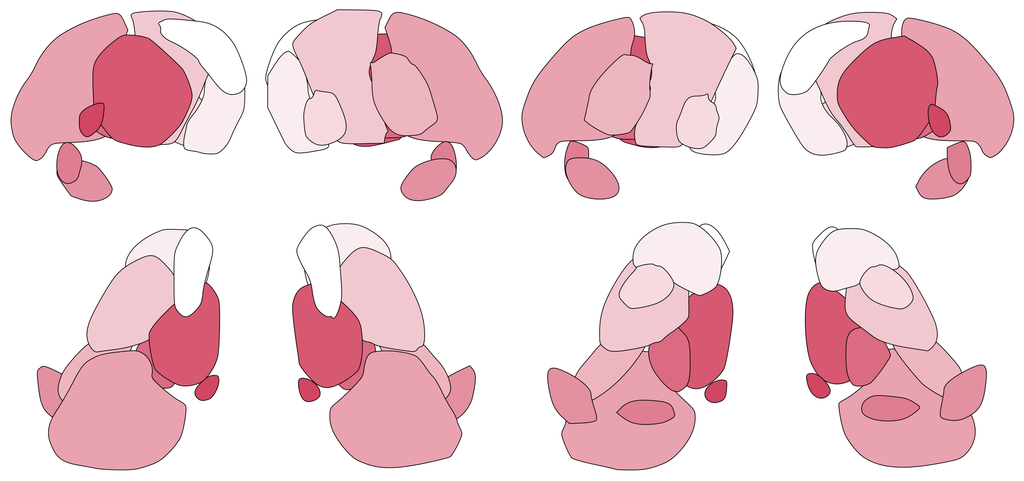

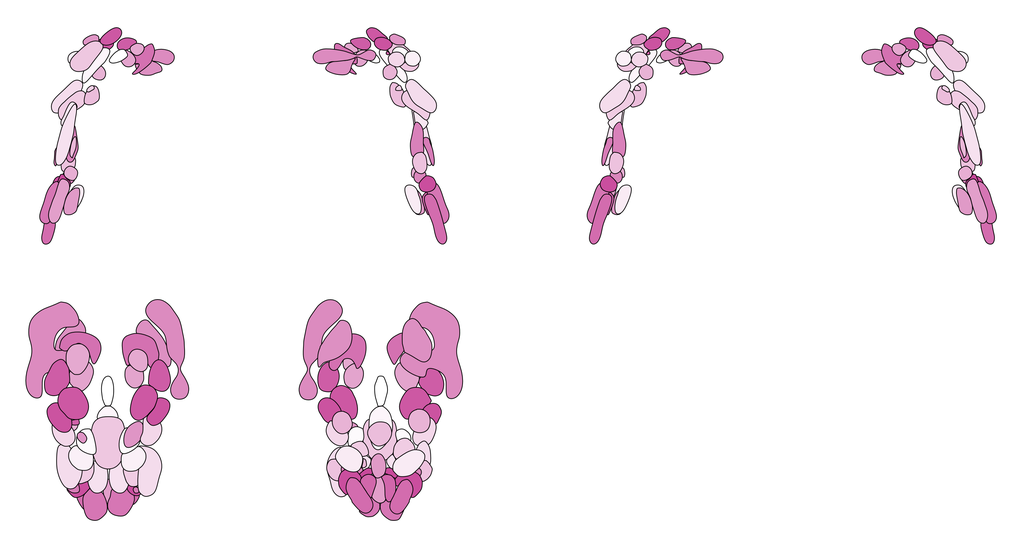

## 3. Controlling transparency

### Global alpha with `fill_alpha`

The `fill_alpha` argument controls the overall opacity of all regions (0 = fully transparent, 1 = fully opaque). This is particularly useful for atlases with many overlapping nuclei, where reducing transparency helps resolve individual regions. Here we loop through five alpha values for the Melbourne Subcortex S2 atlas:

```python
import numpy as np
from subcortex_visualization.plotting import plot_subcortical_data

for fill_alpha in np.arange(0.2, 1.1, 0.2):
    this_alpha_plot = plot_subcortical_data(atlas='Melbourne_S2', fill_alpha=fill_alpha,
                                            cmap='plasma', show_legend=False)
```

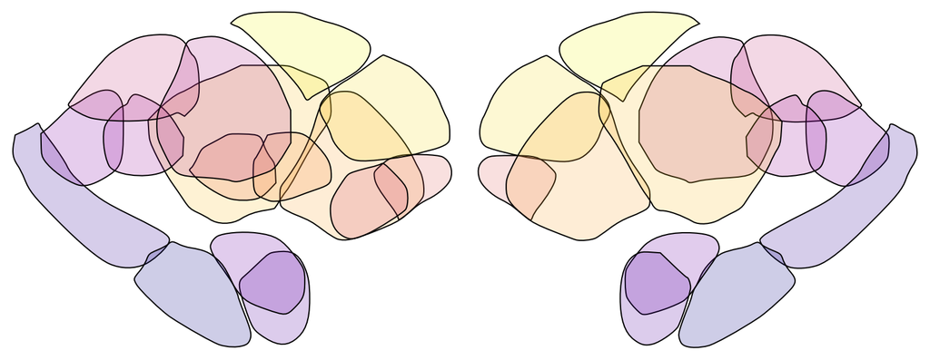

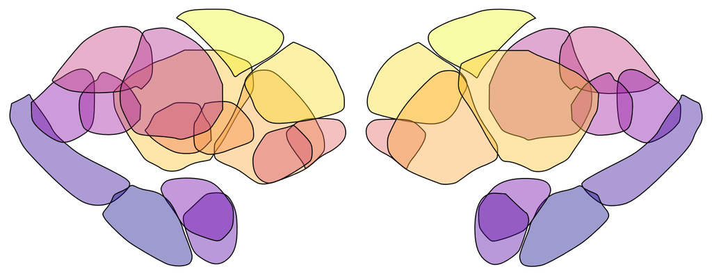

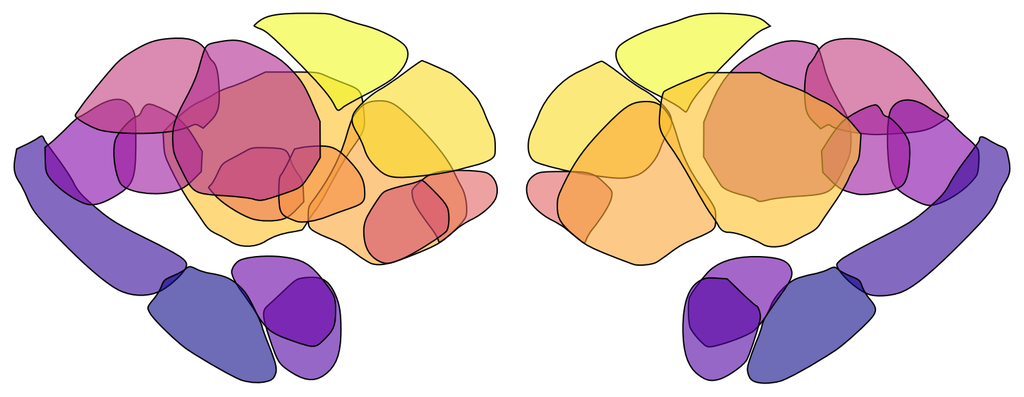

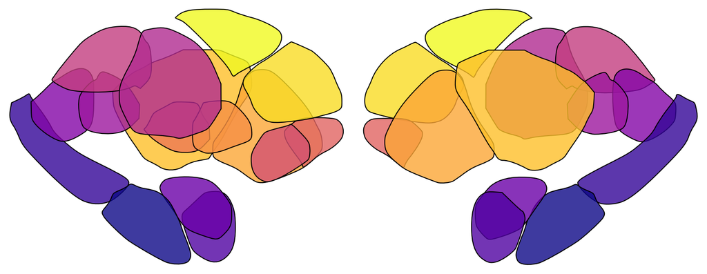

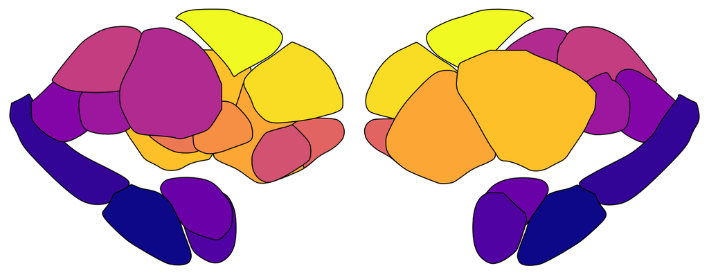

### Significance-based transparency

`plot_subcortical_data` also supports significance-based transparency through `fill_by_significance=True`. When enabled:

- Regions with `p_value < 0.05` are rendered at `fill_alpha` (default 1.0) with full-weight borders
- Regions with `p_value >= 0.05` are rendered at `nonsig_fill_alpha` (default 0.5) with borders at `0.25 × line_thickness`

This requires a `p_value` column in your `subcortex_data` DataFrame. Here we simulate data for the SUIT cerebellar lobule atlas and flag the four regions with the largest absolute effect size as significant:

```python
from subcortex_visualization.plotting import plot_subcortical_data
from subcortex_visualization.utils import get_atlas_regions

np.random.seed(128)
this_atlas = 'SUIT_cerebellar_lobule'
this_atlas_hemisphere_regions, this_atlas_vermis_regions = get_atlas_regions(this_atlas)

this_atlas_simdata = pd.DataFrame({
    'region': np.concatenate([this_atlas_hemisphere_regions,
                              this_atlas_hemisphere_regions,
                              this_atlas_vermis_regions]),
    'Hemisphere': (['L'] * len(this_atlas_hemisphere_regions) +
                  ['R'] * len(this_atlas_hemisphere_regions) +
                  ['V'] * len(this_atlas_vermis_regions))
})
this_atlas_simdata['value'] = np.random.normal(loc=0, scale=1, size=len(this_atlas_simdata))
this_atlas_simdata['p_value'] = np.random.uniform(low=0.05, high=1.0, size=len(this_atlas_simdata))

# Set the four largest-magnitude values to be significant (p < 0.05)
largest_indices = np.argsort(np.abs(this_atlas_simdata['value']))[-4:]
this_atlas_simdata.loc[largest_indices, 'p_value'] = 0.01

this_atlas_simdata.head()
```

|  | region | Hemisphere | value | p_value |
| --- | --- | --- | --- | --- |
| 0 | IV | L | -0.399999 | 0.113297 |
| 1 | V | L | 0.619174 | 0.204917 |
| 2 | VI | L | 0.698343 | 0.177087 |
| 3 | Crus_I | L | -1.253281 | 0.673136 |
| 4 | Crus_II | L | 0.459127 | 0.452322 |

```python
plot_subcortical_data(atlas=this_atlas, subcortex_data=this_atlas_simdata, hemisphere='both',
                      midpoint=0, cmap='PiYG', show_legend=True, line_thickness=3,
                      fill_title="Simulated statistical test results",
                      fill_alpha=1.0, fill_by_significance=True, nonsig_fill_alpha=0.5)
```

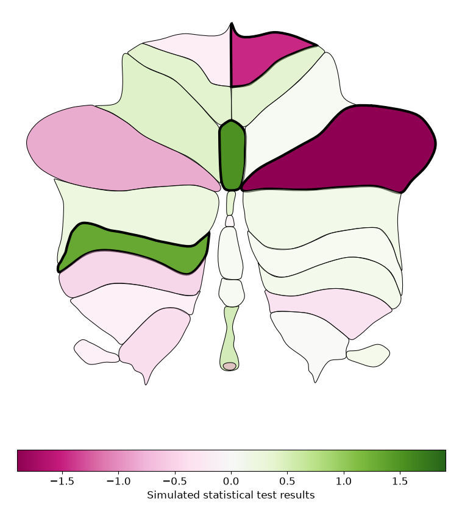